# STATS 506 HW2

Author

Yixuan Jia

## Problem 1

#### (a)

Version 1:

```r
play_dice_1 <- function(n) {
  total <- 0  # Initializing
  for (i in 1:n) {
    roll <- sample(1:6, 1)  # Simulate a dice roll
    if (roll %% 2 == 0) {
      total <- total + roll
    }
  }
  total = total - (2 * n) # cost to play

  return(total)
}
```

Version 2:

```r
play_dice_2 <- function(n) {
  rolls <- sample(1:6, n, replace = TRUE)  # Simulate multiple dice rolls

  winnings <- ifelse(rolls %% 2 == 0, rolls, 0)
  total <- sum(winnings)  # Calculate total winnings

  total = total - (2 * n)

  return(total)
}
```

Version 3:

```r
play_dice_3 <- function(n) {
  # Simulate n dice rolls and create a frequency table of outcomes
  rolls <- table(sample(1:6, n, replace = TRUE))

  # Define the winning numbers (2, 4, 6)
  winning_numbers <- c(2, 4, 6)

  # Calculate the total winnings
  total <- sum(rolls[names(rolls) %in% winning_numbers] * as.integer(names(rolls)[names(rolls) %in% winning_numbers]))

  total = total - (2 * n)

  return(total)
}
```

Version 4:

```r
play_dice_4<- function(n) {
  rolls <- sample(1:6, n, replace = TRUE)

  # Calculate the winnings for each roll
  winnings <- sapply(rolls, function(roll) {
    if (roll %in% c(2, 4, 6)) {
      return(roll)
    } else {
      return(0)
    }
  })

  total <- sum(winnings)

  total = total - (2 * n)

  return(total)
}
```

#### (b)

```r
print(play_dice_1(3))
```

```
[1] -2
```

```r
print(play_dice_1(3000))
```

```
[1] 28
```

```r
print(play_dice_2(3))
```

```
[1] 4
```

```r
print(play_dice_2(3000))
```

```
[1] -92
```

```r
print(play_dice_3(3))
```

```
[1] -6
```

```r
print(play_dice_3(3000))
```

```
[1] -10
```

```r
print(play_dice_4(3))
```

```
[1] 8
```

```r
print(play_dice_4(3000))
```

```
[1] 174
```

#### (c)

```r
n_values <- c(3, 3000)  # Create a vector of n values

for (n in n_values) {
  set.seed(506)
  total1 <- play_dice_1(n)
  cat("Total winnings using version 1 after", n, "rounds", total1, "\n")
  set.seed(506)
  total2 <- play_dice_2(n)
  cat("Total winnings using version 2 after", n, "rounds", total2, "\n")
  set.seed(506)
  total3 <- play_dice_3(n)
  cat("Total winnings using version 3 after", n, "rounds", total3, "\n")
  set.seed(506)
  total4 <- play_dice_4(n)
  cat("Total winnings using version 4 after", n, "rounds", total4, "\n")
}
```

```
Total winnings using version 1 after 3 rounds -6
Total winnings using version 2 after 3 rounds -6
Total winnings using version 3 after 3 rounds -6
Total winnings using version 4 after 3 rounds -6
Total winnings using version 1 after 3000 rounds 82
Total winnings using version 2 after 3000 rounds 82
Total winnings using version 3 after 3000 rounds 82
Total winnings using version 4 after 3000 rounds 82
```

#### (d)

```r
library(microbenchmark)
```

```r
n_low <- 100

# Version 1
microbenchmark(play_dice_1(n_low))
```

```
Unit: microseconds
               expr   min    lq    mean median    uq    max neval
 play_dice_1(n_low) 297.2 347.2 402.481  370.8 388.6 2833.7   100
```

```r
# Version 2
microbenchmark(play_dice_2(n_low))
```

```
Unit: microseconds
               expr  min    lq  mean median   uq  max neval
 play_dice_2(n_low) 13.1 13.75 15.71   14.4 15.8 44.3   100
```

```r
# Version 3
microbenchmark(play_dice_3(n_low))
```

```
Unit: microseconds
               expr  min   lq   mean median   uq   max neval
 play_dice_3(n_low) 58.1 59.6 63.288  60.65 62.8 213.3   100
```

```r
# Version 4
microbenchmark(play_dice_4(n_low))
```

```
Unit: microseconds
               expr   min     lq    mean median     uq   max neval
 play_dice_4(n_low) 103.3 106.95 111.719 109.05 112.85 157.8   100
```

```r
n_large <- 10000

# Version 1
microbenchmark(play_dice_1(n_large))
```

```
Unit: milliseconds
                 expr     min      lq     mean   median       uq     max neval
 play_dice_1(n_large) 35.5001 37.6414 39.38813 38.64975 40.10585 66.0472   100
```

```r
# Version 2
microbenchmark(play_dice_2(n_large))
```

```
Unit: microseconds
                 expr   min     lq    mean median    uq    max neval
 play_dice_2(n_large) 648.7 747.55 825.877 761.95 785.5 5432.1   100
```

```r
# Version 3
microbenchmark(play_dice_3(n_large))
```

```
Unit: microseconds
                 expr   min    lq    mean median    uq    max neval
 play_dice_3(n_large) 716.9 841.3 954.844  864.9 969.1 6053.9   100
```

```r
# Version 4
microbenchmark(play_dice_4(n_large))
```

```
Unit: milliseconds
                 expr    min       lq     mean  median       uq     max neval
 play_dice_4(n_large) 9.5105 10.22635 11.27956 11.1808 11.95955 17.4791   100
```

#### (e)

```r
# Since version 2 is the fastest, I will do simulations using version 2
set.seed(506)
num <- 10000
n <- 300
winnings <- numeric(num)

for (i in 1:num) {
  winnings[i] <- play_dice_2(n)
}
```

```r
t.test(winnings)
```

```
    One Sample t-test

data:  winnings
t = 1.71, df = 9999, p-value = 0.0873
alternative hypothesis: true mean is not equal to 0
95 percent confidence interval:
 -0.1004994  1.4740994
sample estimates:
mean of x
   0.6868
```

From the t-test of 10000 simulations for n = 300 rounds, we can see that the mean of total winnings is 0.6868, which is very close to zero.

Also, the p-value of this test is 0.0873, so we cannot reject the null hypothesis that “the mean of these 10000 simulations is 0.”. Therefore we can conclude that the mean winnings of this dice game is not significantly different from 0. In other words, this is a fair game.

## Problem 2

#### (a)

```r
library(interactions)
library(ggplot2)
library(emmeans)
cars <- read.csv("cars.csv", header = TRUE)
```

```r
new_cols <- c("Height", "Length", "Width",'Driveline','Engine_Type','Engine_Hybrid','Num_Forward_Gears','Transmission','City_mpg','Fuel_Type','Highway_mpg','Classification','ID','Make','Model_Year','Year','Horsepower','Torque')
colnames(cars) <- new_cols
```

#### (b)

```r
cars <- cars[cars["Fuel_Type"] == "Gasoline",]
cars$Year <- factor(cars$Year)
```

#### (c)

```r
model1 <- lm(Highway_mpg ~ Horsepower + Torque + Height + Length + Width + Year, data = cars)

summary(model1)
```

```
Call:
lm(formula = Highway_mpg ~ Horsepower + Torque + Height + Length +
    Width + Year, data = cars)

Residuals:
    Min      1Q  Median      3Q     Max
-10.824  -2.550  -0.452   2.372 202.639

Coefficients:
              Estimate Std. Error t value Pr(>|t|)
(Intercept) 32.2926630  0.7225982  44.690  < 2e-16 ***
Horsepower   0.0163556  0.0022772   7.182 7.96e-13 ***
Torque      -0.0507425  0.0022030 -23.034  < 2e-16 ***
Height       0.0099079  0.0011267   8.794  < 2e-16 ***
Length       0.0017290  0.0008836   1.957   0.0504 .
Width       -0.0003343  0.0009045  -0.370   0.7117
Year2010    -0.4539681  0.6768246  -0.671   0.5024
Year2011     0.1711016  0.6757043   0.253   0.8001
Year2012     1.3029279  0.6810076   1.913   0.0558 .
---
Signif. codes:  0 '***' 0.001 '**' 0.01 '*' 0.05 '.' 0.1 ' ' 1

Residual standard error: 4.602 on 4582 degrees of freedom
Multiple R-squared:  0.4192,    Adjusted R-squared:  0.4182
F-statistic: 413.3 on 8 and 4582 DF,  p-value: < 2.2e-16
```

Based on the output, Highway_mpg increases 0.0164 when Horsepower increases 1 unit.

Also, we can see that the p-values are less than 0.05 for Horsepower, Torque, and Height, so these three are significant predictors for Highway_mpg. Horsepower and Height have positive effects on Highway_mpg while Torque has negative effects on that.

#### (d)

```r
model2 <- lm(Highway_mpg ~ Horsepower + Torque + Height + Length + Width + Year + Horsepower * Torque, data = cars)
summary(model2)
```

```
Call:
lm(formula = Highway_mpg ~ Horsepower + Torque + Height + Length +
    Width + Year + Horsepower * Torque, data = cars)

Residuals:
    Min      1Q  Median      3Q     Max
-11.109  -2.313  -0.258   2.062 203.540

Coefficients:
                    Estimate Std. Error t value Pr(>|t|)
(Intercept)        4.219e+01  7.930e-01  53.199  < 2e-16 ***
Horsepower        -1.666e-02  2.539e-03  -6.563 5.84e-11 ***
Torque            -8.606e-02  2.533e-03 -33.972  < 2e-16 ***
Height             6.560e-03  1.070e-03   6.133 9.32e-10 ***
Length             1.777e-03  8.318e-04   2.136   0.0327 *
Width             -1.169e-03  8.521e-04  -1.372   0.1700
Year2010          -5.628e-01  6.372e-01  -0.883   0.3771
Year2011           7.254e-02  6.361e-01   0.114   0.9092
Year2012           1.197e+00  6.411e-01   1.867   0.0619 .
Horsepower:Torque  1.124e-04  4.628e-06  24.276  < 2e-16 ***
---
Signif. codes:  0 '***' 0.001 '**' 0.01 '*' 0.05 '.' 0.1 ' ' 1

Residual standard error: 4.333 on 4581 degrees of freedom
Multiple R-squared:  0.4854,    Adjusted R-squared:  0.4844
F-statistic: 480.1 on 9 and 4581 DF,  p-value: < 2.2e-16
```

```r
print(summary(cars$Torque))
```

```
   Min. 1st Qu.  Median    Mean 3rd Qu.    Max.
   98.0   177.0   257.0   267.2   332.0   774.0
```

```r
value_counts <- table(cars$Torque)
sorted_counts <- sort(value_counts, decreasing = TRUE)
print(sorted_counts[1:10])
```

```
270 424 260 172 385 420 248 128 190 177
134 106  99  90  90  90  88  84  84  83
```

We can see that the values 270, 424, 172 are quite representative for the whole data set and they have more entries which makes the regression more likely to be accurate. So I will use there three values for the plot.

```r
print(summary(cars$Horsepower))
```

```
   Min. 1st Qu.  Median    Mean 3rd Qu.    Max.
  100.0   185.0   263.0   267.5   317.0   638.0
```

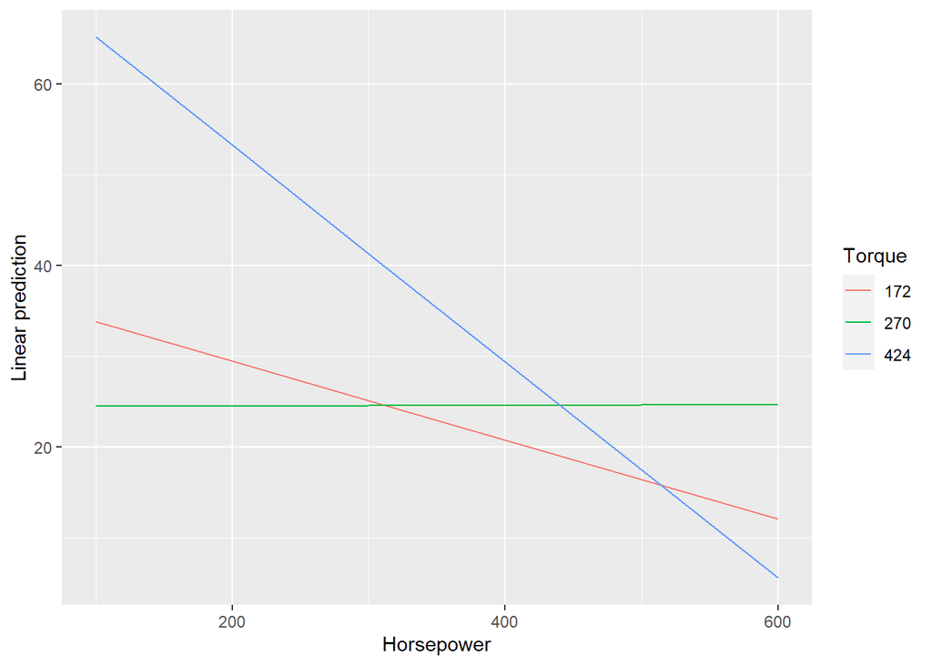

```r
filtered_cars <- subset(cars, Torque %in% c(172, 270, 424))
filtered_cars$Torque <- as.factor(filtered_cars$Torque)
model3 <- lm(Highway_mpg ~ Horsepower + Torque + Height + Length + Width + Year + Horsepower * Torque, data = filtered_cars)

emmip(model3, Torque ~ Horsepower, at = list(Horsepower = c(100, 200, 300, 400, 500, 600)))
```

We can see from the plot that for Torque = 172 and 424, there is a obvious negative relationship between Horsepower and Highway_mpg.

And for Torque = 270, there is a slightly positive relationship between Horsepower and Highway_mpg.

#### (e)

```r
cars$interaction = cars$Horsepower * cars$Torque

cols = cars[, c("Horsepower", "Torque", "Height", "Length", "Width","interaction")]

matrix_columns <- as.matrix(cols)

X <- cbind(1, matrix_columns)

y <- cars$Highway_mpg

#Calculate the coeffience
Beta_hat <- solve(t(X) %*% X) %*% t(X) %*% y

Beta_hat
```

```
                     [,1]
            42.3072130456
Horsepower  -0.0148094308
Torque      -0.0878730895
Height       0.0067152802
Length       0.0014457601
Width       -0.0011013241
interaction  0.0001123363
```

## Problem 3

#### (a)

```stata
. do "C:\Users\11716\AppData\Local\Temp\STD3248_000000.tmp"

. cd "D:\Umich\Sem3\STATS 506\repo_1"
. import delimited "cars.csv"
.
. rename dimensionsheight Height

. rename dimensionslength Length

. rename dimensionswidth Width

. rename engineinformationdriveline Driveline

. rename engineinformationenginetype Engine_Type

. rename engineinformationhybrid Engine_Hybrid

. rename engineinformationnumberofforward Num_Forward_Gears

. rename engineinformationtransmission Transmission

. rename fuelinformationcitympg City_mpg

. rename fuelinformationfueltype Fuel_Type

. rename fuelinformationhighwaympg Highway_mpg

. rename identificationclassification Classification

. rename identificationid ID

. rename identificationmake Make

. rename identificationmodelyear Model_Year

. rename identificationyear Year

. rename engineinformationenginestatistic Horsepower

. rename v18 Torque

end of do-file

.
```

#### (b)

```stata
. do "C:\Users\11716\AppData\Local\Temp\STD3248_000000.tmp"

. keep if Fuel_Type == "Gasoline"
(485 observations deleted)

.
end of do-file
```

#### (c)

```stata
. do "C:\Users\11716\AppData\Local\Temp\STD3248_000000.tmp"

. . regress Highway_mpg c.Horsepower c.Torque c.Height c.Length c.Width i.Year

      Source |       SS           df       MS      Number of obs   =     4,591
-------------+----------------------------------   F(8, 4582)      =    413.35
       Model |  70043.6695         8  8755.45869   Prob > F        =    0.0000
    Residual |   97055.298     4,582  21.1818634   R-squared       =    0.4192
-------------+----------------------------------   Adj R-squared   =    0.4182
       Total |  167098.968     4,590  36.4050038   Root MSE        =    4.6024

------------------------------------------------------------------------------
 Highway_mpg | Coefficient  Std. err.      t    P>|t|     [95% conf. interval]
-------------+----------------------------------------------------------------
  Horsepower |   .0163556   .0022772     7.18   0.000     .0118913      .02082
      Torque |  -.0507425    .002203   -23.03   0.000    -.0550614   -.0464236
      Height |   .0099079   .0011267     8.79   0.000      .007699    .0121168
      Length |    .001729   .0008836     1.96   0.050    -3.36e-06    .0034613
       Width |  -.0003343   .0009045    -0.37   0.712    -.0021075    .0014388
             |
        Year |
       2010  |  -.4539681   .6768246    -0.67   0.502     -1.78087    .8729342
       2011  |   .1711016   .6757043     0.25   0.800    -1.153604    1.495808
       2012  |   1.302928   .6810076     1.91   0.056    -.0321751    2.638031
             |
       _cons |   32.29266   .7225982    44.69   0.000     30.87602     33.7093
------------------------------------------------------------------------------

.
end of do-file

.
```

Same results as Problem 2. Highway_mpg increases 0.0164 when Horsepower increases 1 unit.

The p-values are less than 0.05 for Horsepower, Torque, and Height, so these three are significant predictors for Highway_mpg. Horsepower and Height have positive effects on Highway_mpg while Torque has negative effects on that.

#### (d)

```stata
. do "C:\Users\11716\AppData\Local\Temp\STD3248_000000.tmp"

. regress Highway_mpg c.Horsepower c.Torque c.Height c.Length c.Width i.Year

      Source |       SS           df       MS      Number of obs   =     4,591
-------------+----------------------------------   F(8, 4582)      =    413.35
       Model |  70043.6695         8  8755.45869   Prob > F        =    0.0000
    Residual |   97055.298     4,582  21.1818634   R-squared       =    0.4192
-------------+----------------------------------   Adj R-squared   =    0.4182
       Total |  167098.968     4,590  36.4050038   Root MSE        =    4.6024

------------------------------------------------------------------------------
 Highway_mpg | Coefficient  Std. err.      t    P>|t|     [95% conf. interval]
-------------+----------------------------------------------------------------
  Horsepower |   .0163556   .0022772     7.18   0.000     .0118913      .02082
      Torque |  -.0507425    .002203   -23.03   0.000    -.0550614   -.0464236
      Height |   .0099079   .0011267     8.79   0.000      .007699    .0121168
      Length |    .001729   .0008836     1.96   0.050    -3.36e-06    .0034613
       Width |  -.0003343   .0009045    -0.37   0.712    -.0021075    .0014388
             |
        Year |
       2010  |  -.4539681   .6768246    -0.67   0.502     -1.78087    .8729342
       2011  |   .1711016   .6757043     0.25   0.800    -1.153604    1.495808
       2012  |   1.302928   .6810076     1.91   0.056    -.0321751    2.638031
             |
       _cons |   32.29266   .7225982    44.69   0.000     30.87602     33.7093
------------------------------------------------------------------------------

. .

. . regress Highway_mpg c.Horsepower##c.Torque c.Height c.Length c.Width

      Source |       SS           df       MS      Number of obs   =     4,591
-------------+----------------------------------   F(6, 4584)      =    686.16
       Model |   79064.613         6  13177.4355   Prob > F        =    0.0000
    Residual |  88034.3545     4,584  19.2047021   R-squared       =    0.4732
-------------+----------------------------------   Adj R-squared   =    0.4725
       Total |  167098.968     4,590  36.4050038   Root MSE        =    4.3823

---------------------------------------------------------------------------------------
          Highway_mpg | Coefficient  Std. err.      t    P>|t|     [95% conf. interval]
----------------------+----------------------------------------------------------------
           Horsepower |  -.0148094   .0025612    -5.78   0.000    -.0198306   -.0097882
               Torque |  -.0878731   .0025559   -34.38   0.000    -.0928839   -.0828623
                      |
c.Horsepower#c.Torque |   .0001123   4.68e-06    24.00   0.000     .0001032    .0001215
                      |
               Height |   .0067153    .001078     6.23   0.000     .0046019    .0088287
               Length |   .0014458   .0008401     1.72   0.085    -.0002013    .0030928
                Width |  -.0011013   .0008609    -1.28   0.201    -.0027891    .0005864
                _cons |   42.30721   .5144734    82.23   0.000      41.2986    43.31583
---------------------------------------------------------------------------------------

.
end of do-file

.
```

Below is for the plot:

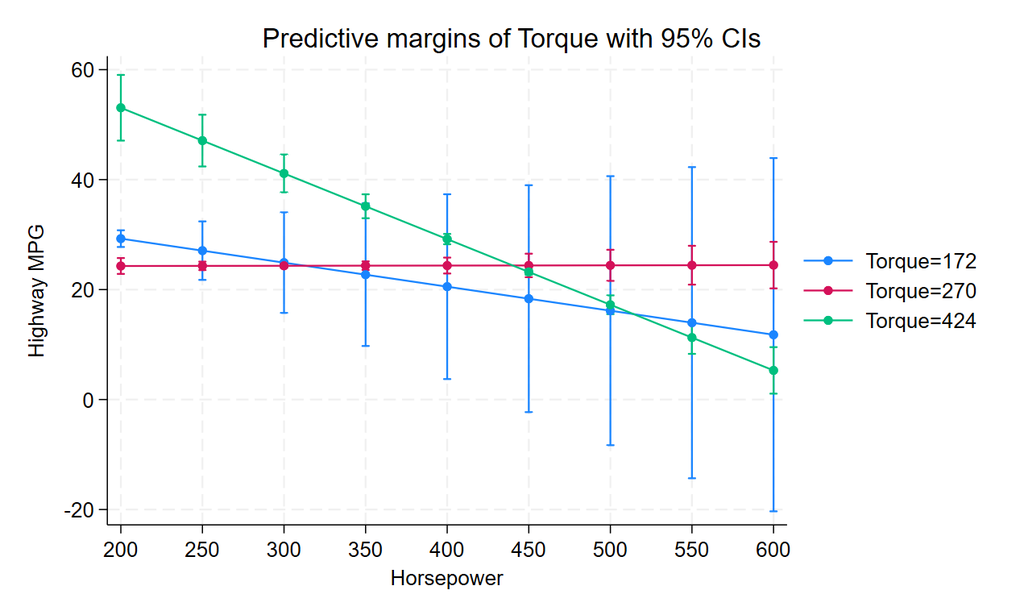

```stata
. keep if Torque == 172 | Torque == 270 | Torque == 424
(4,261 observations deleted)

. . regress Highway_mpg c.Horsepower##i.Torque c.Height c.Length c.Width i.Year

      Source |       SS           df       MS      Number of obs   =       330
-------------+----------------------------------   F(11, 318)      =    102.58
       Model |  2625.27142        11  238.661039   Prob > F        =    0.0000
    Residual |  739.883122       318  2.32667648   R-squared       =    0.7801
-------------+----------------------------------   Adj R-squared   =    0.7725
       Total |  3365.15455       329  10.2284333   Root MSE        =    1.5253

-------------------------------------------------------------------------------------
        Highway_mpg | Coefficient  Std. err.      t    P>|t|     [95% conf. interval]
--------------------+----------------------------------------------------------------
         Horsepower |  -.0436885    .038945    -1.12   0.263     -.120311     .032934
                    |
             Torque |
               270  |   -13.7935   7.451872    -1.85   0.065     -28.4547    .8677032
               424  |   38.94594   9.012624     4.32   0.000     21.21404    56.67785
                    |
Torque#c.Horsepower |
               270  |   .0440871   .0398659     1.11   0.270     -.034347    .1225213
               424  |  -.0757316   .0410262    -1.85   0.066    -.1564488    .0049855
                    |
             Height |  -.0021365   .0017023    -1.26   0.210    -.0054857    .0012128
             Length |   .0027855   .0013118     2.12   0.034     .0002047    .0053663
              Width |   -.009217   .0019866    -4.64   0.000    -.0131256   -.0053085
                    |
               Year |
              2010  |  -1.235853   .8104016    -1.52   0.128    -2.830279    .3585732
              2011  |  -1.102701   .8086546    -1.36   0.174     -2.69369    .4882882
              2012  |  -.2921526   .8133018    -0.36   0.720    -1.892285     1.30798
                    |
              _cons |   39.84346   7.108412     5.61   0.000       25.858    53.82892
-------------------------------------------------------------------------------------

. . margins Torque, at(Horsepower = (200(50)600))

Predictive margins                                         Number of obs = 330
Model VCE: OLS

Expression: Linear prediction, predict()
1._at: Horsepower = 200
2._at: Horsepower = 250
3._at: Horsepower = 300
4._at: Horsepower = 350
5._at: Horsepower = 400
6._at: Horsepower = 450
7._at: Horsepower = 500
8._at: Horsepower = 550
9._at: Horsepower = 600

------------------------------------------------------------------------------
             |            Delta-method
             |     Margin   std. err.      t    P>|t|     [95% conf. interval]
-------------+----------------------------------------------------------------
  _at#Torque |
      1 172  |   29.26736   .7721136    37.91   0.000     27.74826    30.78646
      1 270  |   24.29129   .7336017    33.11   0.000     22.84797    25.73462
      1 424  |   53.06697   3.037173    17.47   0.000     47.09148    59.04246
      2 172  |   27.08294   2.704019    10.02   0.000     21.76291    32.40296
      2 270  |   24.31123   .3938553    61.73   0.000     23.53633    25.08612
      2 424  |   47.09597   2.391566    19.69   0.000     42.39068    51.80126
      3 172  |   24.89851   4.648747     5.36   0.000     15.75233     34.0447
      3 270  |   24.33116    .166234   146.37   0.000      24.0041    24.65822
      3 424  |   41.12496   1.746941    23.54   0.000     37.68794    44.56198
      4 172  |   22.71409   6.594965     3.44   0.001     9.738812    35.68937
      4 270  |   24.35109   .3945969    61.71   0.000     23.57474    25.12744
      4 424  |   35.15396   1.105023    31.81   0.000     32.97988    37.32804
      5 172  |   20.52967   8.541655     2.40   0.017     3.724371    37.33496
      5 270  |   24.37103   .7343984    33.19   0.000     22.92613    25.81592
      5 424  |   29.18295   .4768648    61.20   0.000     28.24474    30.12116
      6 172  |   18.34524   10.48855     1.75   0.081    -2.290481    38.98097
      6 270  |   24.39096   1.085604    22.47   0.000     22.25509    26.52684
      6 424  |   23.21194   .2660397    87.25   0.000     22.68852    23.73536
      7 172  |   16.16082   12.43556     1.30   0.195     -8.30555    40.62719
      7 270  |    24.4109   1.439893    16.95   0.000     21.57797    27.24382
      7 424  |   17.24094    .866722    19.89   0.000      15.5357    18.94617
      8 172  |    13.9764   14.38264     0.97   0.332    -14.32075    42.27354
      8 270  |   24.43083   1.795442    13.61   0.000     20.89838    27.96327
      8 424  |   11.26993   1.506217     7.48   0.000     8.306524    14.23334
      9 172  |   11.79197   16.32975     0.72   0.471    -20.33603    43.91998
      9 270  |   24.45076   2.151625    11.36   0.000     20.21754    28.68398
      9 424  |   5.298928   2.150169     2.46   0.014     1.068574    9.529281
------------------------------------------------------------------------------

. . marginsplot, xtitle(Horsepower) ytitle("Highway MPG")

Variables that uniquely identify margins: Horsepower Torque

.
end of do-file

.
```